# Replicating the Vox lead risk map for CT

Andrew Ba Tran

April 6, 2016

This is an exploratory map going over the steps described by [Sarah Frostenson](https://github.com/voxmedia/data-projects/tree/master/vox-lead-exposure-risk) at Vox and Rad Cunningham from the Washington State Department of Health that estimates a neighborhood’s risk for lead exposure. It inspired the TrendCT.org story [Which neighborhoods have the highest risk of lead poisoning in CT?](http://trendct.org/2016/04/08/where-the-risk-for-lead-poisoning-in-connecticut-is-highest/)

Check out the Vox story this was based on: [The risk of lead poisoning isn’t just in Flint. So we mapped the risk in every neighborhood in America.](http://www.vox.com/a/lead-exposure-risk-map)

### Overview

**What’s going on here**

- Pulling housing and poverty data by census tract from the Census via the excellent [censusapi R package](https://github.com/hrecht/censusapi)
- Calculating a housing score based on weighted categorizations of home ages
- Determining percent of those living beneath the poverty line by census tract
- Getting a Z score for housing and poverty
- Creating an overall score by combining both poverty and housing Z scores (after adjusting them a bit)
- Splitting the range of results between 1 and 10, creating an overall score
- Joining the results to a census tract shape file and mapping it
- Evolution of this methodology: STATA script via WA-DOH -> Python script via Vox -> R script via TrendCT.org

First, load a bunch of packages.

```r
library(dplyr)
library(scales)
require(rgdal)
require(ggmap)
require(Cairo)
require(maptools)
library(ggplot2)
#devtools::install_github("hrecht/censusapi")
library(censusapi)
source("keys.R")
library(DT)
```

Then, pull the data via the Census API - [censusapi R package](https://github.com/hrecht/censusapi).

And assess the lead risk based on a [formula by WA-DOH](https://assets.documentcloud.org/documents/2644455/Expert-Panel-Childhood-Lead-Screening-Guidelines.pdf).

```r
housing <- getCensus(name="acs5",
                      vintage=2014,
                      key=censuskey,
                      vars=c("NAME", "B25034_001E", "B25034_002E", "B25034_003E",
                             "B25034_004E","B25034_005E","B25034_006E","B25034_007E",
                             "B25034_008E","B25034_009E","B25034_010E", "B17004_001E"),
                      region="tract:*", regionin="state:09")

# Change state FIPS code above for a tract data for a different state-- but you'll need to bring in the matching shape file

# You can only pull one state at a time but you can loop the function to get tracts for all states with this code

# tracts <- NULL
## For all states in the fips list
# for (f in fips) {
    ## Define what state to get
    # stateget <- paste("state:", f, sep="")
    ## Get data for all tracts within that state
    # temp <- getCensus(name="acs5", vintage=2014,
    # key=censuskey,
    # vars=c("NAME", "B25034_001E", "B25034_002E", "B25034_003E",
    #                         "B25034_004E","B25034_005E","B25034_006E","B25034_007E",
    #                         "B25034_008E","B25034_009E","B25034_010E", "B17004_001E"),
    # region="tract:*", regionin=stateget)
    ## Bind to existing data
    # tracts <- rbind(tracts, temp)
# }
## You can apply this to poverty below, too

old <- housing

old$age_39 <- old$B25034_010E * .68
old$age40_59 <- (old$B25034_009E + old$B25034_008E) * .43
old$age60_79 <- (old$B25034_007E + old$B25034_006E) * .08
old$age80_99 <- (old$B25034_005E + old$B25034_004E) * .03
old$age00_10 <- (old$B25034_003E + old$B25034_002E) * 0
old$total <-  old$B25034_001E

old$risk_sum <- old$age_39 + old$age40_59 + old$age60_79 + old$age80_99 + old$age80_99 + old$age00_10
old$risk <- old$risk_sum/old$total*100
old <- subset(old, total>0)


## Displaying the new columns of the downloaded dataframe

datatable(head(old[c("NAME", "total", "risk_sum", "risk")]))
```

|  | NAME | total | risk_sum | risk |
| --- | --- | --- | --- | --- |
| 1 | Census Tract 101.01, Fairfield County, Connecticut | 1589 | 389.03 | 24.4826935179358 |
| 2 | Census Tract 101.02, Fairfield County, Connecticut | 1570 | 303.53 | 19.3331210191083 |
| 3 | Census Tract 102.01, Fairfield County, Connecticut | 1049 | 393.25 | 37.4880838894185 |
| 4 | Census Tract 102.02, Fairfield County, Connecticut | 1865 | 407.88 | 21.8702412868633 |
| 5 | Census Tract 103, Fairfield County, Connecticut | 1571 | 633.44 | 40.3208147676639 |
| 6 | Census Tract 104, Fairfield County, Connecticut | 2240 | 566.41 | 25.2861607142857 |

S1701 (part of the original Vox methodology) is not accessible via the Census API but I found the equivalent in B06012.

```r
poverty <- getCensus(name="acs5",
                      vintage=2014,
                      key=censuskey,
                      vars=c("NAME", "B06012_001E", "B06012_002E"
                      ),
                      region="tract:*", regionin="state:09")

poverty$percent_poverty <- poverty$B06012_002E/poverty$B06012_001E * 100
poverty <- subset(poverty, B06012_001E>0)

## Displaying the first few rows of the downloaded dataframe

datatable(head(poverty[c("NAME", "B06012_001E", "B06012_002E", "percent_poverty")]))
```

|  | NAME | B06012_001E | B06012_002E | percent_poverty |
| --- | --- | --- | --- | --- |
| 1 | Census Tract 101.01, Fairfield County, Connecticut | 4103 | 375 | 9.13965391177187 |
| 2 | Census Tract 101.02, Fairfield County, Connecticut | 4130 | 268 | 6.48910411622276 |
| 3 | Census Tract 102.01, Fairfield County, Connecticut | 3189 | 83 | 2.60269677014738 |
| 4 | Census Tract 102.02, Fairfield County, Connecticut | 5065 | 83 | 1.63869693978282 |
| 5 | Census Tract 103, Fairfield County, Connecticut | 4197 | 95 | 2.26352156302121 |
| 6 | Census Tract 104, Fairfield County, Connecticut | 5701 | 225 | 3.94667602175057 |

Determining the Z score now.

```r
# (x-mean(x))/sd(x)

poverty$z_poverty <- (poverty$percent_poverty - mean(poverty$percent_poverty))/sd(poverty$percent_poverty)
old$z_housing <-  (old$risk - mean(old$risk))/sd(old$risk)

# Calcuating weighted figures

poverty$weighted_poverty <- poverty$z_poverty * .42
old$weighted_housing <- old$z_housing * .58

# join dataframes

poverty$tract_id <- paste0(poverty$state, poverty$county, poverty$tract)
old$tract_id <- paste0(old$state, old$county, old$tract)

old <- old[c("tract_id", "risk", "z_housing", "weighted_housing")]

df <- left_join(poverty, old)
df$riskscore_raw <- df$weighted_housing + df$weighted_poverty

# calculating deciles on risk score

df <- mutate(df, quantile = ntile(riskscore_raw, 10))
df$id <- df$tract

## Displaying the new columns of the downloaded dataframe
datatable(head(df[c("id", "z_poverty", "weighted_poverty", "risk", "z_housing", "weighted_housing", "riskscore_raw", "quantile")]))
```

|  | id | z_poverty | weighted_poverty | risk | z_housing | weighted_housing | riskscore_raw | quantile |
| --- | --- | --- | --- | --- | --- | --- | --- | --- |
| 1 | 010101 | -0.212435999017071 | -0.08922311958717 | 24.4826935179358 | -0.421593151066918 | -0.244524027618812 | -0.333747147205982 | 5 |
| 2 | 010102 | -0.424624830947817 | -0.178342428998083 | 19.3331210191083 | -0.861754613519628 | -0.499817675841384 | -0.678160104839467 | 3 |
| 3 | 010201 | -0.735749804549741 | -0.309014917910891 | 37.4880838894185 | 0.690047018477948 | 0.40022727071721 | 0.0912123528063186 | 7 |
| 4 | 010202 | -0.812922472020459 | -0.341427438248593 | 21.8702412868633 | -0.644893394898527 | -0.374038169041146 | -0.715465607289738 | 3 |
| 5 | 010300 | -0.76290235649984 | -0.320418989729933 | 40.3208147676639 | 0.932175654668106 | 0.540661879707501 | 0.220242889977569 | 7 |
| 6 | 010400 | -0.628158018115199 | -0.263826367608384 | 25.2861607142857 | -0.352916518927323 | -0.204691580977847 | -0.468517948586231 | 4 |

## Generating the map

Download the census blocks for other states from the Census.

```r
# Setting up the environment to handle spatial information
gpclibPermit()
```

```
## [1] TRUE
```

```r
gpclibPermitStatus()
```

```
## [1] TRUE
```

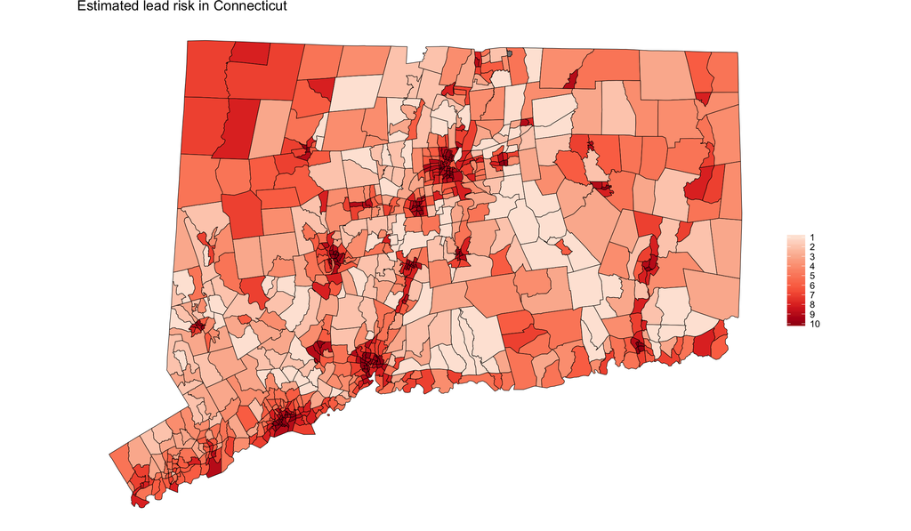

```r
# Bringing in the shapefiles in a folder downloaded from the Census
# Find other states here https://www.census.gov/geo/maps-data/data/cbf/cbf_tracts.html

censustracts <- readOGR(dsn="maps/census_tracts/wgs84", layer="tractct_37800_0000_2010_s100_census_1_shp_wgs84")
censustracts <- fortify(censustracts, region="TRACTCE10")

risk_map <- left_join(censustracts, df)
ggplot() +
  geom_polygon(data = risk_map, aes(x=long, y=lat, group=group, fill=quantile), color = "black", size=0.2) +
  coord_map() +
  scale_fill_distiller(type="seq", trans="reverse", palette = "Reds", breaks=pretty_breaks(n=10)) +
  theme_nothing(legend=TRUE) +
  labs(title="Estimated lead risk in Connecticut", fill="")
```